# KNN Lab

Group 10: Megan Lin, Eva Mustafic, James Powell

4/1/2021

## Instructions

You left your job as a tracking unstructured text as you wanting to expand your skills into predictive models. Luckily you landed a job in advertising! Unfortunately have a demanding and totally clueless boss. Clueless meaning that he doesn’t understand data science, but he knows he wants it to be used to fix all the company’s problems and you are just the data scientist to do it!

Your company, Marketing Enterprises of Halifax or “MEH” is being beat out by the competition and wants a new way to determine the quality of its commercials. Your boss, Mr. Ed Rooney, would like the company’s commercials to seem more like actual TV shows. So he wants you to develop a “machine learning thing” using the company’s internal data to classify when something is a commercial and when it is not. Mr. Rooney believes the company will be able to make more convincing commercials that hold audiences attention if they are more like tv shows and as a result customers will pay more attention, thus buy more of the terrible products “MEH” is supporting (it’s a terrible plan, but you have to make a living).

Given that MEH is producing commercials more or less continuously you know there will be a need to update the model quite frequently, also being a newish data scientist and having a clueless boss you decide to use a accessible approach that you might be able to explain to Mr. Rooney, (given several months of dedicated one on one time), that approach is k-nearest neighbor.

You’ll also need to document your work extensively, because Mr. Rooney doesn’t know he’s clueless so he will ask lots of “insightful” questions and require lots of detail that he won’t understand, so you’ll need to have an easy to use reference document. Before you get started you hearken back to the excellent education you received at UVA and using this knowledge outline roughly 15 steps that need to be completed to build this algo for MEH and Ed, they are documented below…good luck. As always, the most important part is translating your work to actionable insights, so please make sure to be verbose in the explanation required for step 15. Think about this questions carefully, what are you really delivering to Mr. Rooney?

As with the clustering lab, please be prepared to present a five minute overview of your findings.

## Prepare the Data

First, we read in both the clean commercial dataset and the labels for their columns, omitting any NAs. After this we renamed the columns of the clean commercial dataset with the names stored in labels. For some reason “shot_length” was the names of the column in this dataset, so we just decided to hard code the names into the columns.

## Split the Data

To determine the split, we had to determine the ratio of commercial to total, and based on that, we can deduce the percent of non-commercial entries, and the percentage of both. To do this we created the function ad_split, which prints the ratio of commercial to total entries and ran it on the clean commercial dataset. The split between commercial to non-commercial is 64 percent to 36 percent, respectively.

## Choose the Data

To filter out the vars, we create a list of the vars names and saved the dataset over itself without the columns in the vars variable.

|  | shot_length | motion_distr_mn | frame_diff_dist_mn | short_time_energy_mn | zcr_mn | spectral_centroid_mn | spectral_roll_off_mn | spectral_flux_mn | fundamental_freq_mn | motion_dist_mn | label |
| --- | --- | --- | --- | --- | --- | --- | --- | --- | --- | --- | --- |
| 1 | 29 | 3.821209 | 13.547628 | 0.019883 | 0.067241 | 3406.8662 | 6796.552 | 1021.359192 | 102.60780 | 0.538928 | 1 |
| 2 | 25 | 3.052969 | 22.334589 | 0.023027 | 0.077000 | 3324.1582 | 6610.000 | 1199.364380 | 84.68770 | 0.446286 | 1 |
| 3 | 82 | 1.601274 | 5.860583 | 0.025948 | 0.082317 | 3771.9841 | 7488.112 | 1544.147461 | 92.69461 | 0.591414 | 1 |
| 4 | 25 | 4.819368 | 41.382828 | 0.014387 | 0.069875 | 3301.6860 | 6606.001 | 599.555176 | 96.59550 | 0.246416 | 1 |
| 5 | 29 | 2.768753 | 13.338054 | 0.011506 | 0.100647 | 3266.0215 | 6688.795 | 446.452423 | 95.03695 | 0.314103 | 1 |
| 6 | 25 | 3.679925 | 27.195999 | 0.012956 | 0.068125 | 3324.5254 | 6565.001 | 637.621582 | 109.96493 | 0.270214 | 1 |
| 7 | 113 | 2.782705 | 11.439361 | 0.016132 | 0.100719 | 3836.2617 | 7486.948 | 829.102234 | 124.97644 | 0.399679 | 1 |
| 8 | 161 | 1.403820 | 6.740815 | 0.016213 | 0.125213 | 3883.3008 | 7499.845 | 832.503845 | 131.13185 | 0.420022 | 1 |
| 9 | 81 | 0.984162 | 6.858030 | 0.016380 | 0.110147 | 3795.9250 | 7359.878 | 948.118774 | 122.91135 | 0.657833 | 1 |
| 10 | 116 | 1.262012 | 6.325819 | 0.015549 | 0.122683 | 3853.6484 | 7461.855 | 728.807373 | 124.33065 | 0.678812 | 1 |

[output cut: 9990 more lines]

Afterwards, we just simply had to run the function cor(), to discover how each column was related to each other to.

We will choose to only get rid of motion_distr_mean because it is highly correlated with two other categories (frame_diff_dist_mn and motion_dist_mn)based on the threshold of .7 and -.7. Therefore motion_distr_mn is the the optimal removal choice. And after this set our data is finished being cleaned, and we are ready to use KNN!

## Generate Training and Testing Sets

### Data Sets

#### Training Data

|  | shot_length | frame_diff_dist_mn | short_time_energy_mn | zcr_mn | spectral_centroid_mn | spectral_roll_off_mn | spectral_flux_mn | fundamental_freq_mn | motion_dist_mn | label |
| --- | --- | --- | --- | --- | --- | --- | --- | --- | --- | --- |
| 16605 | 28 | 10.919862 | 0.015575 | 0.113728 | 3426.024 | 6638.394 | 966.2574 | 110.65646 | 0.518807 | 1 |
| 6927 | 94 | 17.287212 | 0.008855 | 0.122806 | 3745.876 | 7403.992 | 425.6229 | 133.60312 | 0.320269 | 1 |
| 9657 | 82 | 35.006763 | 0.024365 | 0.073552 | 3764.459 | 7450.307 | 1907.5811 | 125.46422 | 0.152643 | 1 |
| 14313 | 32 | 42.724541 | 0.006376 | 0.081738 | 3424.360 | 6829.689 | 183.5159 | 96.27204 | 0.301346 | 1 |
| 21870 | 84 | 3.738151 | 0.024549 | 0.097954 | 3806.777 | 7409.225 | 1898.3185 | 117.84273 | 0.851909 | 1 |
| 21278 | 25 | 18.405970 | 0.009217 | 0.107875 | 3277.616 | 6460.999 | 671.2277 | 106.68487 | 0.200106 | -1 |

#### Testing Data

|  | shot_length | frame_diff_dist_mn | short_time_energy_mn | zcr_mn | spectral_centroid_mn | spectral_roll_off_mn | spectral_flux_mn | fundamental_freq_mn | motion_dist_mn | label |
| --- | --- | --- | --- | --- | --- | --- | --- | --- | --- | --- |
| 4 | 25 | 41.382828 | 0.014387 | 0.069875 | 3301.686 | 6606.001 | 599.5552 | 96.5955 | 0.246416 | 1 |
| 6 | 25 | 27.195999 | 0.012956 | 0.068125 | 3324.525 | 6565.001 | 637.6216 | 109.9649 | 0.270214 | 1 |
| 9 | 81 | 6.858030 | 0.016380 | 0.110147 | 3795.925 | 7359.878 | 948.1188 | 122.9113 | 0.657833 | 1 |
| 18 | 37 | 9.313793 | 0.010304 | 0.090541 | 3549.011 | 6901.352 | 621.8444 | 130.8351 | 0.574563 | 1 |
| 19 | 30 | 12.463446 | 0.005663 | 0.126667 | 3427.363 | 6668.333 | 261.9821 | 105.8174 | 0.318818 | 1 |
| 20 | 101 | 6.009381 | 0.018699 | 0.101516 | 3823.747 | 7425.496 | 2045.5127 | 132.8565 | 0.721467 | 1 |

## When K=3

Next, we will look at what happens if we base our heuristic/algorithm only based off of each data point’s 3 neighbors (k=3).

### Confusion Matrix

```
##
## tv_3NN   -1    1
##     -1  846  472
##     1   776 2415
```

```
## [1]  846 2415
```

```
## [1] 0.8365085
```

```
## Confusion Matrix and Statistics
##
##           Actual
## Prediction   -1    1
##         -1  846  472
##         1   776 2415
##
##                Accuracy : 0.7232
##                  95% CI : (0.7099, 0.7362)
##     No Information Rate : 0.6403
##     P-Value [Acc > NIR] : < 2.2e-16
##
##                   Kappa : 0.3734
##
##  Mcnemar's Test P-Value : < 2.2e-16
##
##             Sensitivity : 0.8365
##             Specificity : 0.5216
##          Pos Pred Value : 0.7568
##          Neg Pred Value : 0.6419
##              Prevalence : 0.6403
##          Detection Rate : 0.5356
##    Detection Prevalence : 0.7077
##       Balanced Accuracy : 0.6790
##
##        'Positive' Class : 1
##
```

[output not shown]

## Choosing the Best K

|  | K | Accuracy |
| --- | --- | --- |
| 1 | 1 | 0.6992681 |
| 2 | 3 | 0.7236638 |
| 3 | 5 | 0.7398536 |
| 4 | 7 | 0.7420714 |
| 5 | 9 | 0.7471723 |
| 7 | 13 | 0.7498337 |
| 6 | 11 | 0.7504990 |
| 8 | 15 | 0.7511643 |
| 9 | 17 | 0.7524950 |
| 10 | 19 | 0.7551564 |

[output cut: 1 more lines]

Based on the chooseK function, K=21 seems to have the highest accuracy of 0.757 as shown in column 11. K-1 has the lowest accuracy of 0.699.

## Choosing a K

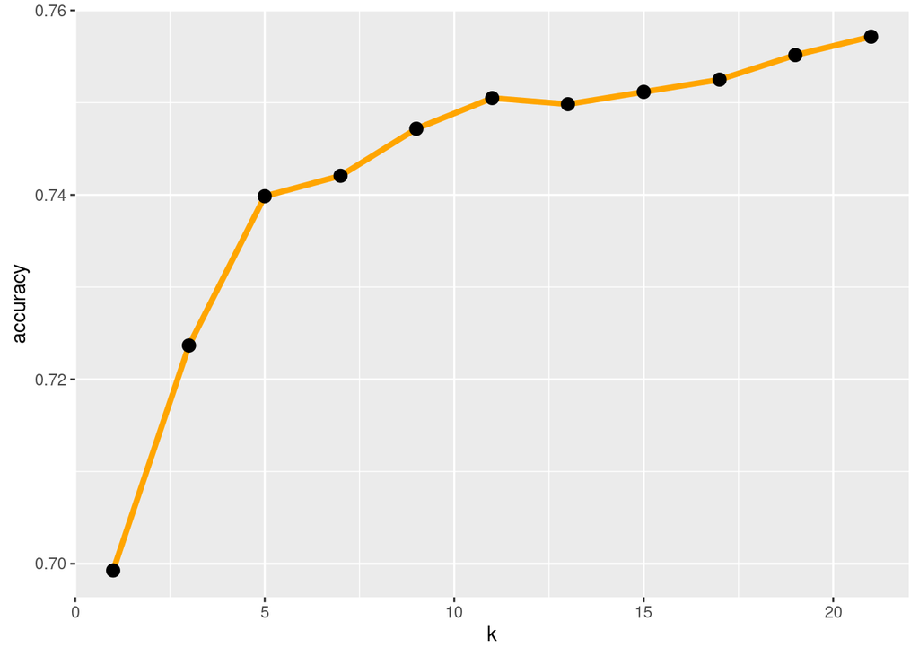

9 to 11 is the best choice here because that’s the greatest improvement in predictive accuracy before the incremental improvement trails off.

With a k of 9, we now get an accuracy of 74.7% and a sensitivity of 89.6% which is slightly better than the previous k=3’s value of 72.3% accuracy & 83.7% sensitivity.

## Mr. Rooney’s Interpretation

Mr. Rooney, this algorithm, K next neighbor, will be very beneficial to Marketing Enterprises of Halifax. It is able to accurately predict which time slot will have a commercial or not. It takes a group of commercials and can accurately tell you when a commercial is. The model we will propose is accurate 75% where we would normally only be able to guess around 64% of commercials timing. Which means that if we use this model to determine when time slots are given to commercials, we will be able to better predict the audience base who will be watching at these key times.

We compared two methods to determine which could better predict when a time slot would be a commercial or not. Both methods relied on the given data set from CNN which were then split into one dataset to train our algorithm on (aka the representative data set), and another to test our algorithm on (testing the value/scoring system the representative data set created on).

One relied on comparing the datapoint to 3 of its neighboring data points while the other with 9 neighboring datapoints. The method where we compared using 9 neighbors (74.7% accurate, 89.6% sensotove) to predict if a time slot was a commercial or not was 2.4% more accurate and 5.9% more sensitive than the method that only used 3 neighbors (72.3% accurate, 83.7% sensitive), so I would recommend that we proceed with the 9 neighbors model as we will be able to better predict when we will be able to get our commercials in. The 9 neighbors model will not only be more sensitive to smaller changes in what is going on live, but will be able to more accurately determine if a time slot is a commercial or not.